# workflow

This document discusses the typical workflow and highlights some key considerations when performing Monte Carlo simulations of financial asset markets using MCmarket.

## Monte Carlo Framework

This example generates k periods of returns for D Assets across N counter-factual markets.

Before performing any simulations, one must first consider the type of market that they want to simulate. This involves deciding on how to set the market’s covariance matrix, choosing what multivariate distribution to use, how to set asset return distributions and their time-series properties. Since the correlation matrix is the key input when simulating markets in MCmarket, lets start by looking at some. Users can estimate their own correlation matrices with real world data, or create *ad hoc* matrices to simulate markets with specific dependence structures.

### ad hoc/ constructed correlation matricies

- The function *gen_corr* allows users to easily generate *ad hoc* correlation matrices with a set number of clusters and up to four layers.

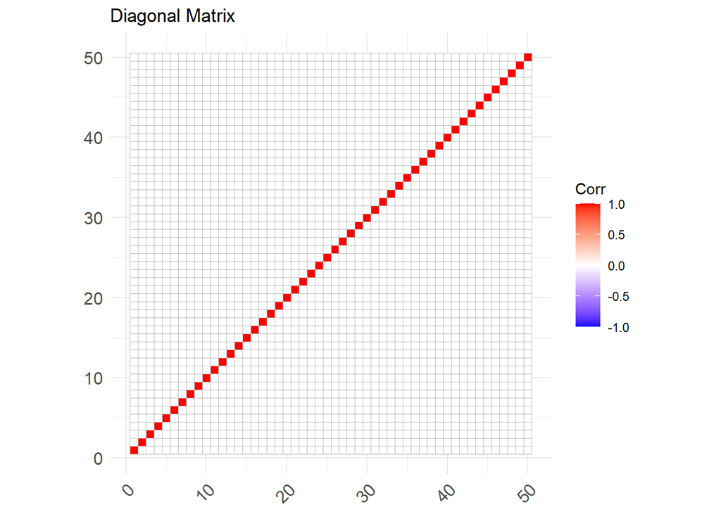

```r
pacman::p_load(MCmarket, tidyverse, ggcorrplot)

# First look at the diagonal correlation matrix
corr_1 <- diag(50)
corr_1 %>% ggcorrplot(hc.order = TRUE, title = "Diagonal Matrix")
```

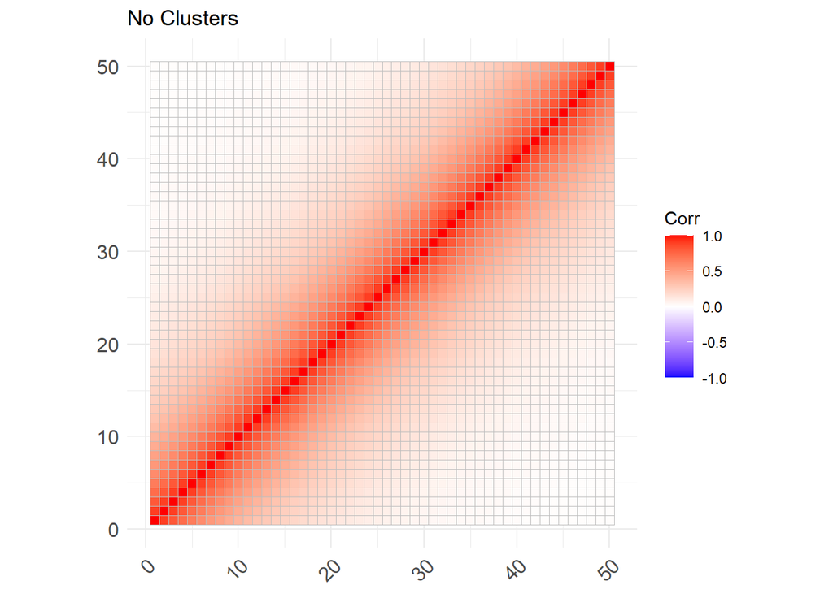

```r
# Correlation matrix with no clusters
corr_2 <- gen_corr(D = 50, clusters = "none")
corr_2 %>% ggcorrplot(title = "No Clusters")
```

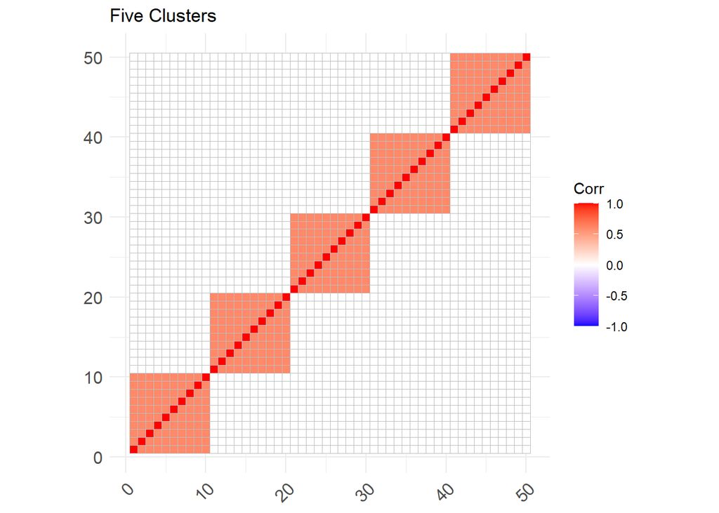

```r
# Correlation matrix with 5 clusters
corr_3 <- gen_corr(D = 50, clusters = "non-overlapping", num_clusters = 5)
corr_3 %>% ggcorrplot(hc.order = TRUE, title = "Five Clusters")
```

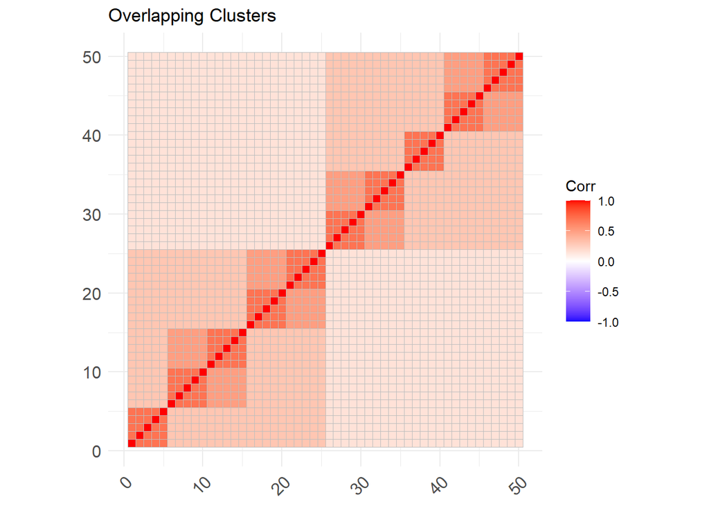

```r
# Correlation matrix with 10, 5 and 2 overlapping clusters
corr_4 <- gen_corr(D = 50, clusters = "overlapping", num_clusters = c(10,5,2))
corr_4 %>% ggcorrplot(hc.order = TRUE, title = "Overlapping Clusters")
```

```r
# The correlation matrix eigenvalues tell us about the markets various risk sources and their importance
tibble(diag = eigen(corr_1)$value, no_clust = eigen(corr_2)$value, five_clust = eigen(corr_3)$value, overlap_clast = eigen(corr_4)$value) %>% head(10)
```

```
## # A tibble: 10 x 4
##     diag no_clust five_clust overlap_clast
##    <dbl>    <dbl>      <dbl>         <dbl>
##  1     1   15.9         6.40         14.4
##  2     1   10.4         6.40          6.89
##  3     1    6.28        6.40          3.3
##  4     1    3.92        6.40          3.3
##  5     1    2.59        6.40          2.49
##  6     1    1.81        0.4           2.46
##  7     1    1.32        0.4           1.3
##  8     1    1.01        0.4           1.30
##  9     1    0.793       0.4           1.30
## 10     1    0.640       0.4           1.30
```

### Emperical

If the *ad hoc* matrices do not seem realistic enough, or the exact correlation structure is not of particular interest, then one can use empirical data to estimate a correlation matrix of their own. Alternatively, *MCmarket* comes with a data set of 30 correlation matrices that were each estimated from a random subset of 50 S&P500 stocks over a random time slice of 252 days between 1 January 2000 and 1 January 2020.

These correlation matrices are labeled as ‘stressed’ if they were estimated on a market where an equi-weighted basket of stocks has a Sharpe ratio below -0.5, ‘rally’ if the equi-weighted basket of stocks has a Sharpe ratio above 2 and ‘normal’ if the equi-weighted basket of stocks has a Sharpe in-between -0.5 and 2. See *MCmarket::corr_mats*.

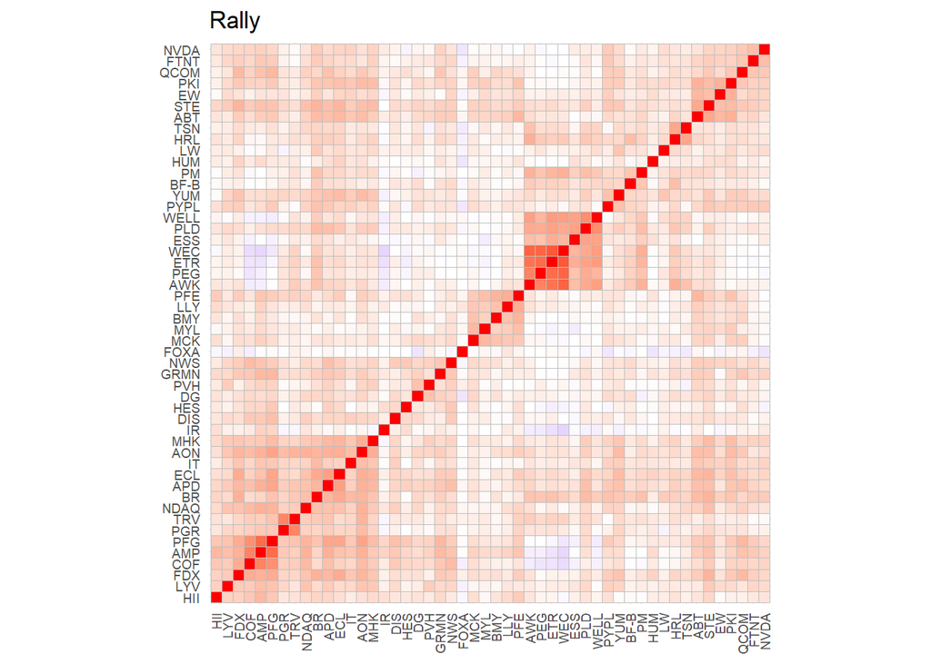

```r
corr_mats$cor_rally[[1]] %>% ggcorrplot(title = "Rally", hc.order = TRUE) +
  theme(legend.position = "none",
        axis.text.y = element_text(size=7),
        axis.text.x = element_text(angle = 90, vjust = 0.5, hjust=1, size=7))
```

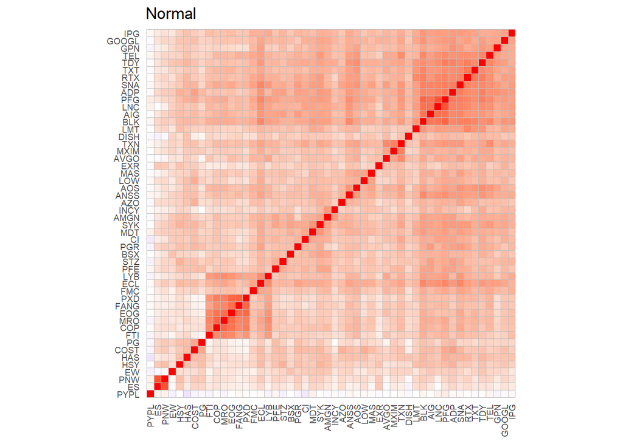

```r
corr_mats$cor_normal[[2]] %>% ggcorrplot(title = "Normal", hc.order = TRUE) +
  theme(legend.position = "none",
        axis.text.y = element_text(size=7),
        axis.text.x = element_text(angle = 90, vjust = 0.5, hjust=1, size=7))
```

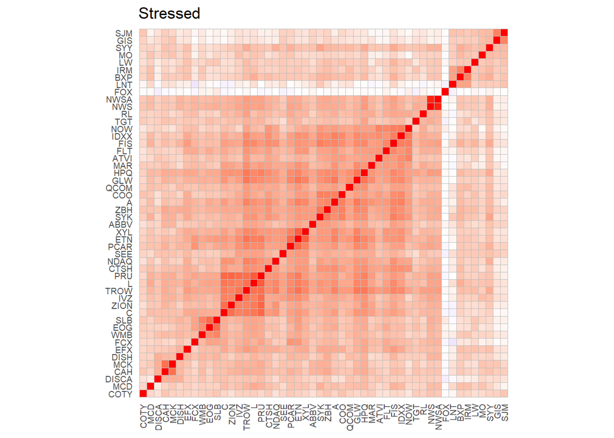

```r
corr_mats$cor_stressed[[2]] %>% ggcorrplot(title = "Stressed", hc.order = TRUE) +
  theme(legend.position = "none",
        axis.text.y = element_text(size=7),
        axis.text.x = element_text(angle = 90, vjust = 0.5, hjust=1, size=7))
```

```r
# The correlation matrix eigenvalues tell us about the markets various risk sources and their importance
tibble(rally = eigen(corr_mats$cor_rally[[1]])$value,
       normal = eigen(corr_mats$cor_normal[[2]])$value,
       stressed = eigen(corr_mats$cor_stressed[[2]])$value) %>% head(10)
```

```
## # A tibble: 10 x 3
##    rally normal stressed
##    <dbl>  <dbl>    <dbl>
##  1  9.42 18.0     18.9
##  2  4.66  3.28     3.11
##  3  2.19  2.20     2.29
##  4  2.03  1.51     1.69
##  5  1.67  1.37     1.58
##  6  1.46  1.30     1.42
##  7  1.40  1.20     1.31
##  8  1.27  1.18     1.12
##  9  1.22  1.06     1.05
## 10  1.20  0.999    0.974
```

## Multivariate Distributions

The 2nd step in deciding what kind of market to simulate is selecting the market’s multivariate distribution. *MCmarket* provides functionality to select between the multivariate normal, t and Clayton copula distribution. The multivariate normal distribution has thin tails and therefore, creates relatively low risk markets, where joint drawdowns are not significantly consequential. The multivariate t distribution has a degrees of freedom parameter that can be adjusted to effect market risk. High degrees of freedom will create markets similar to that of the normal distribution, while low degrees of freedom values will produce markets with fatter tails, this can make joint drawdowns more consequential. The Clayton distribution will produce markets with left-tailed dependence, where asset correlations increase during market drawdowns. The Clayton copula also has a parameter that can be adjusted to effect the degree of left tail dependence. However, when using the Clayton copula option, the simulated markets no longer adhere to the input correlation matrix.

```r
# Using sim_market
set.seed(123)
market_norm <-
    sim_market(
        corr_4,
        # 500 periods
        k = 500,
        mv_dist = "norm",
        # arbitrary mean and sd
        marginal_dist_model = list(mu = 0.002, sd = 0.05)
    )
```

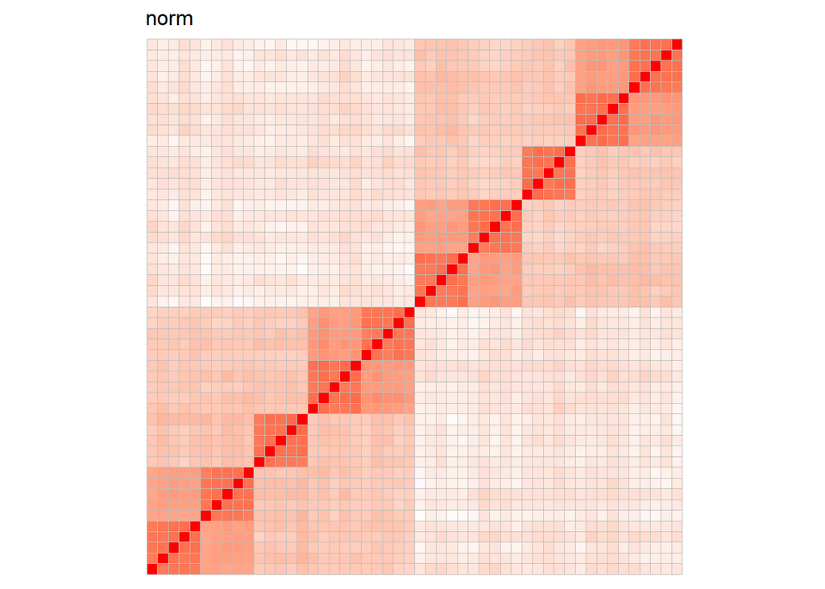

```r
set.seed(123)
market_t <-
    sim_market(
        corr_4,
        k = 500,
        # 500 periods
        mv_dist = "t",
        mv_df = 3,
        marginal_dist_model = list(mu = 0.002, sd = 0.05)
    )


set.seed(123)
market_clay <-
    sim_market(
        corr_4,
        k = 500,
        # 500 periods
        mv_dist = "clayton",
        clayton_param = 0.5,
        marginal_dist_model = list(mu = 0.002, sd = 0.05)
    )

# Plotting Correlation mats
nc <- market_norm %>%
    spread(Asset, Return) %>%
    select(-date) %>%
    cor() %>%
    ggcorrplot(title = "norm", hc.order = TRUE) +
    theme(
        legend.position = "none",
        axis.title.x = element_blank(),
        axis.text.y = element_blank(),
        axis.text.x = element_blank()
    )
nc
```

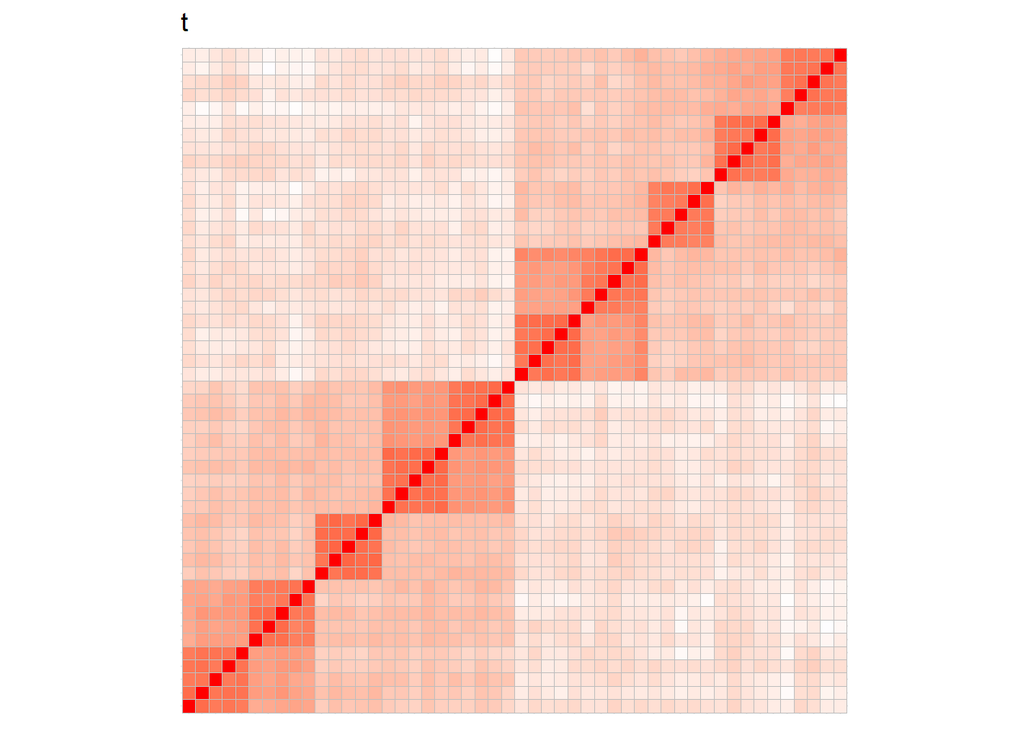

```r
tc <- market_t %>%
    spread(Asset, Return) %>%
    select(-date) %>%
    cor() %>%
    ggcorrplot(title = "t", hc.order = TRUE) +
    theme(
        legend.position = "none",
        axis.title.x = element_blank(),
        axis.text.y = element_blank(),
        axis.text.x = element_blank()
    )
tc
```

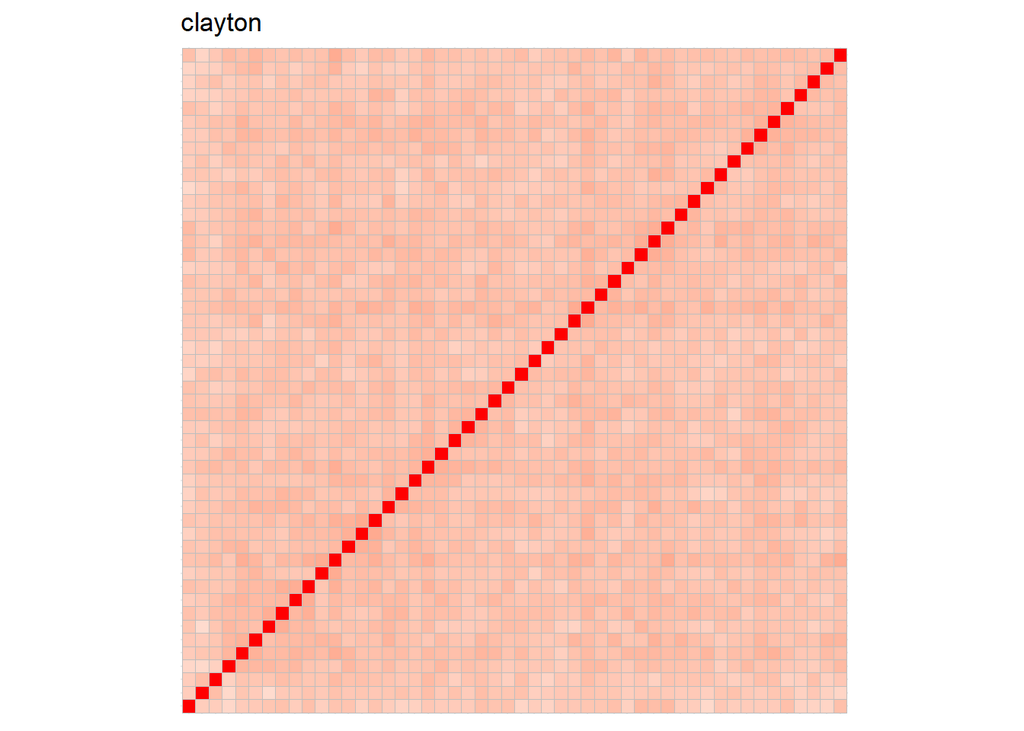

```r
cc <- market_clay %>%
    spread(Asset, Return) %>%
    select(-date) %>%
    cor() %>%
    ggcorrplot(title = "clayton", hc.order = TRUE) +
    theme(
        legend.position = "none",
        axis.title.x = element_blank(),
        axis.text.y = element_blank(),
        axis.text.x = element_blank()
    )
cc
```

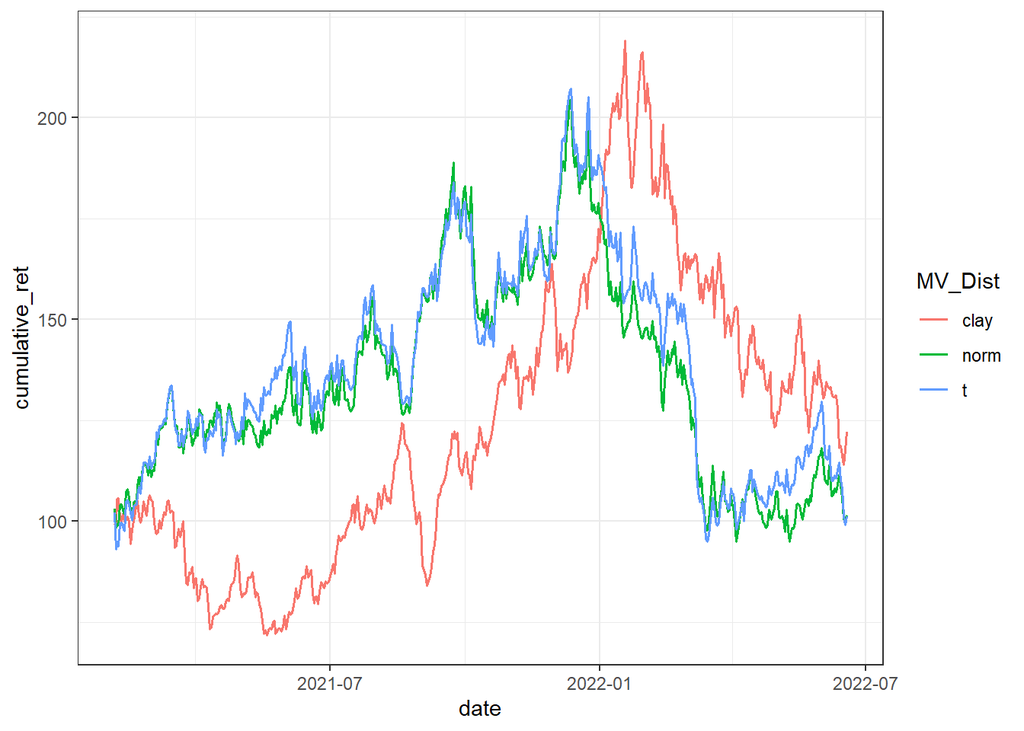

```r
# To see the difference in market dist lets see
# how an equal weighted portfolio does.
pacman::p_load(rmsfuns, tbl2xts)

weights <-
    market_norm  %>% filter(date == first(date)) %>%
    mutate(weight = 1 / n()) %>% select(date, Asset , weight) %>%
    spread(Asset, weight) %>% tbl_xts()

R_norm <- market_norm %>% spread(Asset, Return) %>% tbl_xts()
R_t <- market_t %>% spread(Asset, Return) %>% tbl_xts()
R_clay <- market_clay %>% spread(Asset, Return) %>% tbl_xts()

return_norm <-
    Safe_Return.portfolio(R_norm, weights) %>% xts_tbl() %>%
    mutate(norm = portfolio.returns) %>% select(-portfolio.returns)

return_t <- Safe_Return.portfolio(R_t, weights) %>% xts_tbl() %>%
    mutate(t = portfolio.returns) %>% select(-portfolio.returns)

return_clay <-
    Safe_Return.portfolio(R_clay, weights) %>% xts_tbl() %>%
    mutate(clay = portfolio.returns) %>% select(-portfolio.returns)

# Plotting and compairing cumuative returns over time
left_join(return_norm, return_t) %>% left_join(return_clay) %>%
    gather(MV_Dist, Return,-date) %>%
    group_by(MV_Dist) %>% arrange(date) %>%
    mutate(cumulative_ret = cumprod(1 + Return) * 100) %>%
    ggplot(aes(x = date, y = cumulative_ret, color = MV_Dist)) +
    geom_line(size = 0.7) +
    theme_bw()
```

## Univariate/Marginal Distributions

The next step is to decide on the the individual assets return distributions. *MCmarket* allows one to select between the normal, t and skewed generalized t (sgt) distributions. The sgt is the most general distribution and thereby, nests a number of alternative distributions, including the normal and t.

The first part of this step involves deciding if you want returns to be fat- or thin-tailed. If you want thin-tailed returns, then use the normal distribution or the t distribution with many degrees of freedom. If you want fat tails, then use the t-distribution with few degrees of freedom or the sgt distribution. Finally, if you want control over the skewness and/or kurtosis of the distributions, then use the sgt.

The second part involves deciding how to set the parameters of these distributions across the assets. For example, when using the normal distribution, should all assets have the same mean and sd? or should they have the same mean and different sd, or different means and sd ect.. This is up to the user and depends on the purpose of performing the Monte Carlo simulation.

The code below demonstrates how to select asset distributions using in *MC_market’s sim_market* functions. For simplicity, this example will use the normal distribution.

```r
# Assigning mean = -10 and sd = 20 for all assets
m1 <- sim_market(
  corr_4,
  k = 1000,
  # selecting the pdf for the assets
  marginal_dist = "norm",
  # selecting parameters
  marginal_dist_model = list(# single arguments are assigned to all assets
    mu = -10,
    sd = 20)
)

m1 %>% group_by(Asset) %>%
    mutate(mean = mean(Return), sd = sd(Return))
```

```
## # A tibble: 50,000 x 5
## # Groups:   Asset [50]
##    date       Asset    Return  mean    sd
##    <date>     <glue>    <dbl> <dbl> <dbl>
##  1 2021-02-04 Asset_1   -67.8 -10.5  19.2
##  2 2021-02-04 Asset_2   -66.6 -10.8  19.1
##  3 2021-02-04 Asset_3   -63.1 -10.6  19.0
##  4 2021-02-04 Asset_4   -40.7 -10.6  19.4
##  5 2021-02-04 Asset_5   -65.1 -10.5  19.2
##  6 2021-02-04 Asset_6   -56.0 -10.5  19.6
##  7 2021-02-04 Asset_7   -53.5 -10.9  19.6
##  8 2021-02-04 Asset_8   -64.4 -11.2  19.9
##  9 2021-02-04 Asset_9   -34.0 -10.6  19.8
## 10 2021-02-04 Asset_10  -47.9 -10.6  19.6
## # ... with 49,990 more rows
```

```r
# Assigning a mean of 1:50 and sd = 1:50 for assets 1:50
m2 <- sim_market(
    corr_4,
    k = 1000,
    # selecting the pdf for the assets
    marginal_dist = "norm",
    # selecting parameters
    marginal_dist_model = list( # marginal_dist_model can take any vector of arguments
      mu = 1:50,
      sd = 1:50)
)

m2 %>% group_by(Asset) %>%
    mutate(mean = mean(Return), sd = sd(Return))
```

```
## # A tibble: 50,000 x 5
## # Groups:   Asset [50]
##    date       Asset    Return   mean    sd
##    <date>     <glue>    <dbl>  <dbl> <dbl>
##  1 2021-02-04 Asset_1    1.07  0.989  1.00
##  2 2021-02-04 Asset_2    3.74  1.96   1.95
##  3 2021-02-04 Asset_3    5.24  3.02   3.02
##  4 2021-02-04 Asset_4   10.6   4.09   4.05
##  5 2021-02-04 Asset_5    5.24  4.98   5.05
##  6 2021-02-04 Asset_6   16.6   5.98   6.04
##  7 2021-02-04 Asset_7   17.1   6.90   7.01
##  8 2021-02-04 Asset_8    8.30  8.06   7.84
##  9 2021-02-04 Asset_9   21.7   8.99   8.96
## 10 2021-02-04 Asset_10  23.3  10.1   10.0
## # ... with 49,990 more rows
```

```r
# same mean differnt sd??
m3 <- sim_market(
    corr_4,
    k = 1000,
    # selecting the pdf for the assets
    marginal_dist = "norm",
    # selecting parameters
    marginal_dist_model = list(mu = 1, sd = 1:50)
)
m3 %>% group_by(Asset) %>%
    mutate(mean = mean(Return), sd = sd(Return))
```

```
## # A tibble: 50,000 x 5
## # Groups:   Asset [50]
##    date       Asset    Return  mean    sd
##    <date>     <glue>    <dbl> <dbl> <dbl>
##  1 2021-02-04 Asset_1   0.860 1.00   1.01
##  2 2021-02-04 Asset_2   2.00  1.04   1.97
##  3 2021-02-04 Asset_3   0.813 1.00   3.04
##  4 2021-02-04 Asset_4   1.39  0.912  4.04
##  5 2021-02-04 Asset_5   0.774 1.01   4.88
##  6 2021-02-04 Asset_6   2.65  0.918  6.00
##  7 2021-02-04 Asset_7   3.97  1.05   7.14
##  8 2021-02-04 Asset_8   5.48  0.807  8.02
##  9 2021-02-04 Asset_9   1.09  0.747  8.92
## 10 2021-02-04 Asset_10  1.78  1.12  10.2
## # ... with 49,990 more rows
```

## Time-Series Properties

The final step is to decide on how to assign time-series properties across the assets. *MCmarket* has a function called *sim_garch* that allows users to induce time-series properties into a vector of random numbers by setting the parameters of a ARMA(1,1) + APARCH(1,1) model. The *sim_market* function then uses this function via is *ts_model* argument.

Return momentum can be induced by the ar and ma parameters, volatility persistence can be induced through the beta parameter, a leverage effect can be included through the Gamma parameter ect… The time-series parameters can be set the same across all assets or each asset’s can be set individually.

See ??MCmarket::sim_garch and ??fGarch::garchSpec for more information regarding the ARMA(1,1) + APARCH(1,1) parameters.

Note that when using the *ts_model* argument, the means and sd in *marginal_dist_model* should be left as 0 and 1, respectively. If not, then the moments are set twice and a warning message will appear.

The code below demonstrates how to use *sim_garch* to set the time-series properties of the simulated returns using a toy example.

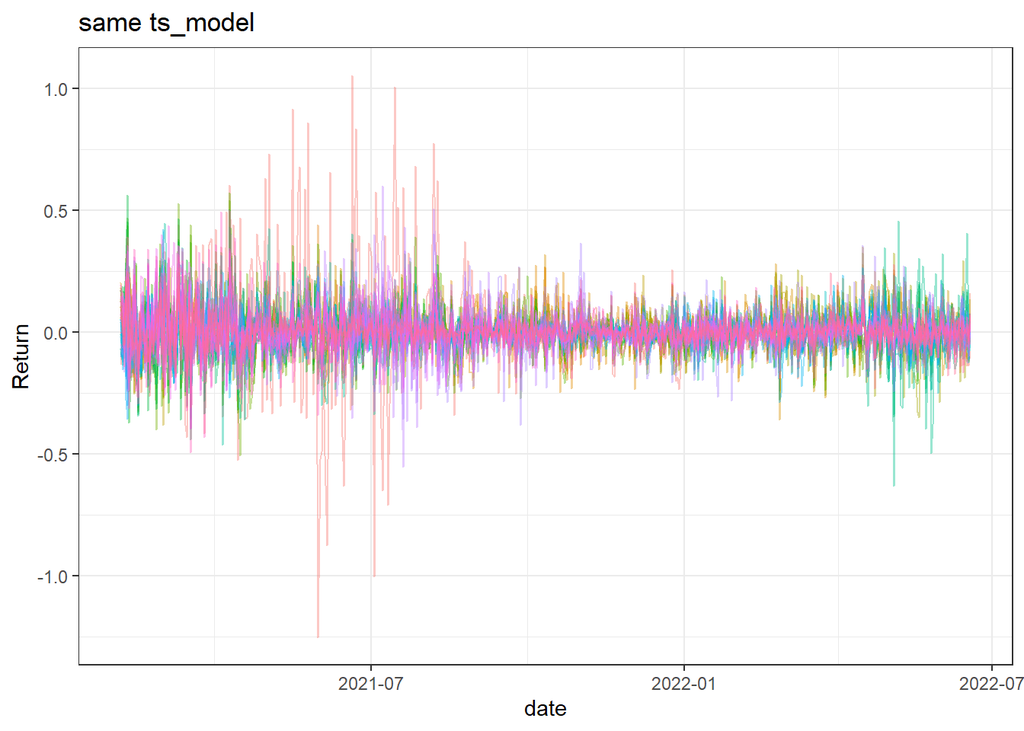

```r
set.seed(1234)
m1 <-
    sim_market(
        corr = corr_4,
        k = 500,
        mv_dist = "t",
        mv_df = 3,
        marginal_dist = "t",
        # same non centrality parameter (ncp) and df for each asset
        marginal_dist_model = list(ncp = 0, df = 20),
        # same ts_model for each asset
        ts_model = list( # Setting the same parameters for each Asset.
            # mean periodic return
            mu = 0.00002,
            # key unconditional volatility parameter
            omega = 0.00002,
            # ARCH effect
            alpha = 0.098839,
            # volatility persistence
            beta = 0.9,
            # autoregressive from ARMA
            ar = 0.063666,
            # moving average from ARMA
            ma = NULL,
            # APARCH leverage parameter
            gamma = 0.00001,
            # APARCH parameter
            delta = 1.85
        )
    )

set.seed(1234)
m2 <-
    sim_market(
        corr = corr_4,
        k = 500,
        mv_dist = "t",
        mv_df = 3,
        marginal_dist = "t",
        # same non centrality parameter (ncp) and df for each asset
        marginal_dist_model = list(ncp = 0, df = 20),
        # different ts model for each asset. at least for beta
        ts_model = list( # Setting different beta parameters for each aset.
            # mean periodic return
            mu = 0.00002,
            # key unconditional volatility parameter
            omega = 0.00002,
            # ARCH effect
            alpha = 0.098839,
            # volatility persistence
            beta = seq(0, 0.99, length.out = 50),
            # autoregressive from ARMA
            ar = 0.063666,
            # moving average from ARMA
            ma = NULL,
            # APARCH leverage parameter
            gamma = 0.00001,
            # APARCH parameter
            delta = 1.85
        )
    )

m1 %>% ggplot(aes(x = date, y = Return, color = Asset)) +
    geom_line(alpha = 0.4) + theme_bw() +
    theme(legend.position = "none") +
    labs(title = "same ts_model")
```

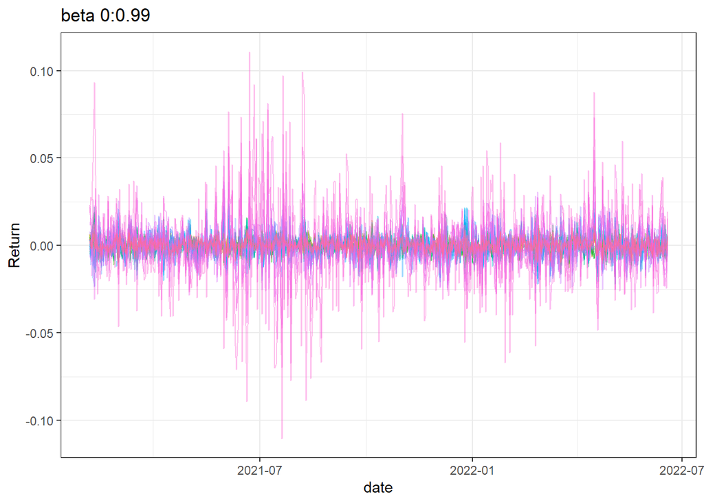

```r
m2 %>% ggplot(aes(x = date, y = Return, color = Asset)) +
    geom_line(alpha = 0.4) + theme_bw() +
    theme(legend.position = "none") +
    labs(title = "beta 0:0.99")
```

# Monte Carlo

Once one knows the properties of the market they wish to simulate, they can perform the Monte Carlo simulation. *MCmarket* provides a function called *mc_market* that enables users who are not comfortable using the *map* functions from the *purrr* package to perform Monte Carlo simulations using *sim_market*. When performing large Monte Carlo simulations, it is recommended that users iterate over *sim_market* by hand (see example below) as they can then use *sim_market’s* progress bar functionality, this is useful because calculations can take a number of minutes to complete.

The code below demonstrates how to use the *mc_market* function, as well as how to use *purrr::map()* and *sim_market* to perform Monte Carlo simulations with a progress bar.

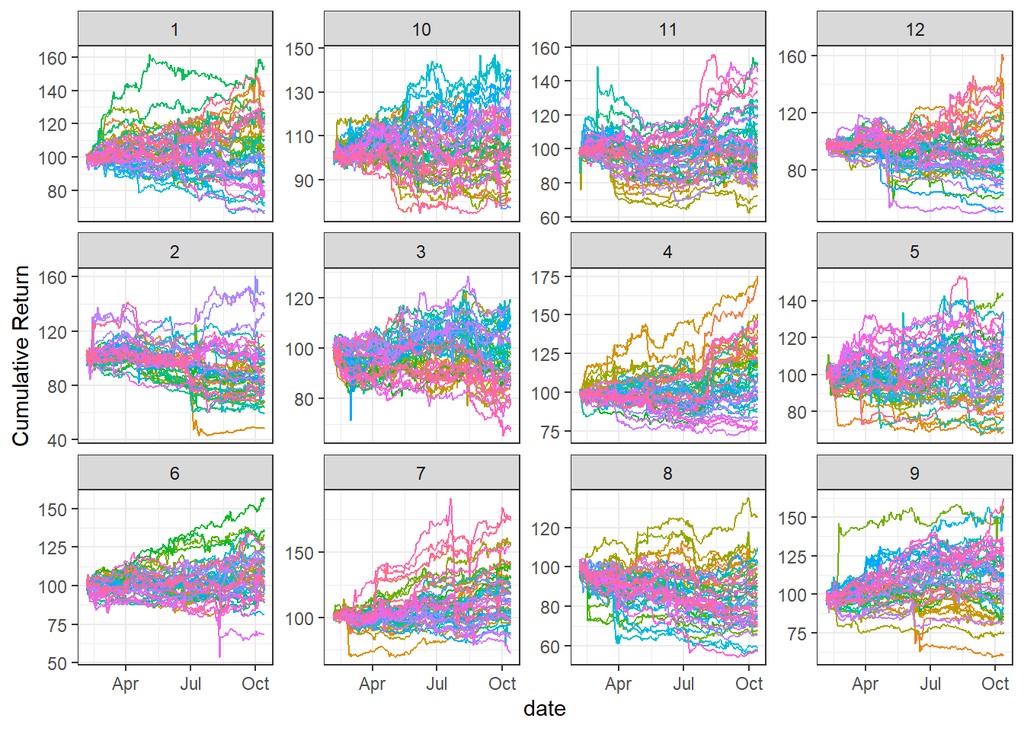

```r
# First using mc_market| Note smaller dimensions and N are used for plotting convenience
set.seed(123)
mc1 <-
  mc_market(
    corr_4,
    N = 12,
    k = 252,
    mv_dist = "norm",
    marginal_dist = "sgt",
    marginal_dist_model = list(
      mu = 0,
      sd = 1,
      lambda = -0.05,
      p = 2,
      q = Inf
    ),
    ts_model = list(
      mu = 0.000002,
      omega = 0.00005,
      alpha = 0.7,
      beta = 0.1,
      ar = 0.05,
      ma = NULL,
      gamma = 0.05,
      delta = 1.9
    ),
    list = FALSE # for long data
  )

# When the output is long it is easy to plot
mc1 %>%
    group_by(Asset, Universe) %>%
    mutate(clumulative_ret = cumprod(1 + Return) * 100) %>%
    ggplot(aes(x = date, y = clumulative_ret, color = Asset)) +
    geom_line() +
    facet_wrap( ~ Universe, scales = "free_y") +
    theme_bw() +
    theme(legend.position = "none") +
  labs(y = "Cumulative Return")
```

See the example of how to perform a large Monte Carlo with a progress bar.

```r
# For large Monte Carlos map by hand with a progress bar.
pacman::p_load(MCmarket, purrr)
N <- 1000
pb <- dplyr::progress_estimated(N)   # this must be named pb

# For large N use map>map_dfr
mc2 <- map(
    1:N,
    ~ sim_market(
        corr_4,
        k = 300,
        mv_dist = "t",
        mv_df = 2.5,
        marginal_dist = "sgt",
        marginal_dist_model = list(
            mu = 0.01,
            sd = 0.1,
            # skewness parameter
            lambda = -0.2,
            # kurtosis parameter 1
            p = 2,
            # kurtosis parameter 2
            q = Inf
        ),
        progress = TRUE
    )
)
```